# Persuasive or Deceptive Visualization - Ravi Tejwani (tejwanir@mit.edu)

# Introduction

The analysis of the more recent years (2000-2022) shows that we have consistent data across different income groups.

- **High income countries:** On average, they spent about 4.65% of their GDP on education, with a relatively stable standard deviation, indicating consistent spending.
- **Low income countries:** These countries spent an average of 3.36% of their GDP on education, also showing consistency but with a slightly lower expenditure percentage compared to other groups.
- **Lower middle-income countries:** The average expenditure here is around 4.40%, which is quite comparable to high-income countries.
- **Upper middle-income countries:** They have an average expenditure of 4.60%, closely aligning with high-income countries.

The global average expenditure on education across all countries in the dataset is approximately 4.34% of GDP, showing a general trend of countries investing a significant portion of their GDP in education.

# Proposition

Based on this data, a potential proposition could be:

**"Despite varying economic standings, countries across different income groups have consistently allocated a substantial portion of their GDP to education, with upper middle-income and high-income countries leading slightly in the percentage of GDP dedicated to education."**

This proposition suggests a global commitment to education, with an interesting note that income level does not drastically change the proportion of GDP countries devote to education, indicating a universally recognized importance of investment in education. It also hints at a convergence in education investment priorities among countries with different income levels, especially in the recent decades.

# Visualization 1: Supporting the Proposition

This visualization illustrates the average government expenditure on education as a percentage of GDP for different income groups over recent years. It aims to support the proposition that despite economic differences, countries across various income levels have allocated a substantial and similar portion of their GDP to education.

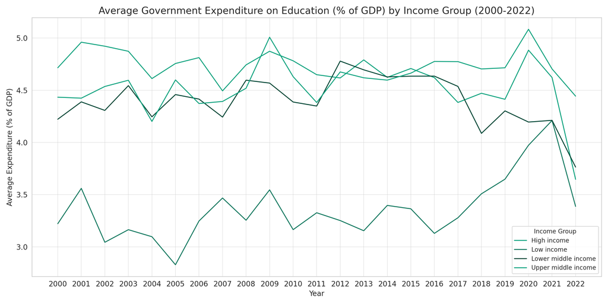

# Visualization 2: Challenging the Proposition

This visualization presents the average standard deviation of government expenditure on education as a percentage of GDP for each income group. This graph aims to challenge the proposition by highlighting the variability in the data, suggesting there may be inconsistencies in how different income groups allocate their education budgets.

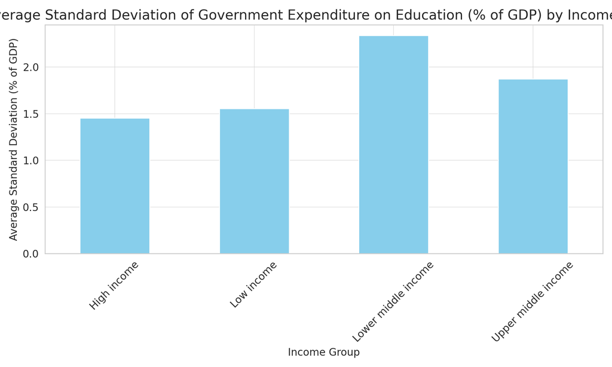

**Design decisions and rationale**

1. Bar Chart of Standard Deviation:
   - Score: 1.5
   - Rationale: The bar chart represents the variability in education spending for each income group, using standard deviation as a measure. This choice leans towards earnest, as it highlights the differences in variability among the groups, suggesting that there might be more to the story than the first visualization shows. However, it's slightly less earnest because focusing solely on variability could overshadow the overall trend of consistent spending seen in the first chart.
2. Color Choice:
   - Score: 2
   - Rationale: The use of a single, non-distracting color (sky blue) ensures that the data stands out without introducing any bias or misleading emphasis. This design decision is earnest, as it maintains the focus on the data itself, allowing for an unbiased interpretation of the variability across different income groups.
3. Simplification by Averaging:
   - Score: 1
   - Rationale: Averaging the standard deviation across years might obscure year-to-year fluctuations but provides a clearer, simplified view of the overall variability in education spending within income groups. This decision is somewhat earnest, aiming to clarify the presentation but potentially masking specific yearly data that could be relevant. It was chosen to balance detail with clarity, ensuring the graph remains interpretable and not cluttered.

# Final Reflection

Reflecting on the overall design process for both visualizations, the most straightforward aspect was selecting the appropriate type of graph to represent the data effectively. Line plots for time-series data and bar charts to showcase variability or standard deviation are conventional choices that align well with the data's nature. These choices ensure that the information is conveyed clearly and can be easily understood by the audience. However, ensuring that these visualizations remained balanced between being persuasive and maintaining integrity was a more nuanced challenge. The aim was to make the visualizations compelling without compromising the data's accuracy or leading to misinterpretations.

A surprising element was how the choice of data representation, like focusing on averages or highlighting variability, could significantly influence the narrative around the data. Even when the data is presented accurately, the framing can shift the audience's perception and interpretation. This underscored the importance of being mindful of the narrative that visualization choices can create, beyond just the raw data.

Defining "ethical analysis and visualization" now feels more nuanced. It involves a commitment to truthfulness, ensuring that the data's presentation doesn't distort its reality, even while attempting to make a persuasive argument. The ethical boundary between "acceptable" persuasive choices and "misleading" ones hinges on whether the visualization remains true to the data. Acceptable persuasive choices are those that aim to highlight or clarify trends, patterns, or outliers in the data, enhancing the viewer's understanding without distorting the truth. Misleading choices, however, involve manipulating the visualization or cherry-picking data in a way that skews the viewer's perception, leading them to possibly erroneous conclusions that the data does not support.

In conclusion, the balance lies in using design to enhance comprehension and convey a narrative without overstepping into manipulation. The goal is to inform and perhaps persuade, but always with a foundation of respect for the data's integrity and the audience's right to an accurate representation. This approach ensures that the persuasive power of visualizations is harnessed responsibly, fostering informed decision-making and discourse.